# arima-garch

Indra Mahib Zuhair Riyanto

2024-10-25

```r
library(ggplot2)
library(tsibble)
library(tseries)
library(MASS)
library(forecast)
library(graphics)
library(TTR)
library(TSA)
library(dplyr)
library(FinTS)
library(fGarch)
library(rugarch)
```

## Data

```r
dt <- read.csv("D:\\IPB\\5\\MPDW\\data\\data_0101-3107_mpdw _csv.csv")
head(dt)
```

```
##      Tanggal ID.Prasarana           Prasarana Penumpang.Berangkat
## 1 2023-01-01          AAP         APT Pranoto                 666
## 2 2023-01-01          AMQ           Pattimura                 476
## 3 2023-01-01          BDJ      Syamsudin Noor                2556
## 4 2023-01-01          BDO Husein Sastranegara                 876
## 5 2023-01-01          BEJ           Kalimarau                 326
## 6 2023-01-01          BIK      Frans Kaisiepo                 311
##   Penumpang.Berangkat.Domestik Penumpang.Berangkat.Internasional Penumpang.Tiba
## 1                          666                                 0            844
## 2                          476                                 0            364
## 3                         2556                                 0           3257
## 4                          876                                 0           1028
## 5                          326                                 0            344
## 6                          311                                 0            177
##   Penumpang.Tiba.Domestik Penumpang.Tiba.Internasional Pesawat.Tiba.Domestik
```

[output cut: 20 more lines]

### Data Selection

```r
dt <- dt %>% filter(ID.Prasarana=="BPN") %>%
  select(Tanggal, Penumpang.Berangkat, Penumpang.Tiba) %>%
  rename(tanggal = Tanggal, brgkt = Penumpang.Berangkat, tiba = Penumpang.Tiba)
str(dt)
```

```
## 'data.frame':    571 obs. of  3 variables:
##  $ tanggal: chr  "2023-01-01" "2023-01-02" "2023-01-03" "2023-01-04" ...
##  $ brgkt  : int  4521 5283 5352 5989 5884 6299 6002 6354 5380 5660 ...
##  $ tiba   : int  5772 6737 7307 7137 7443 6943 6801 7200 7035 7112 ...
```

### Formatting

```r
dt$tanggal <- as.Date(dt$tanggal, format = "%Y-%m-%d")
```

## Eksplorasi

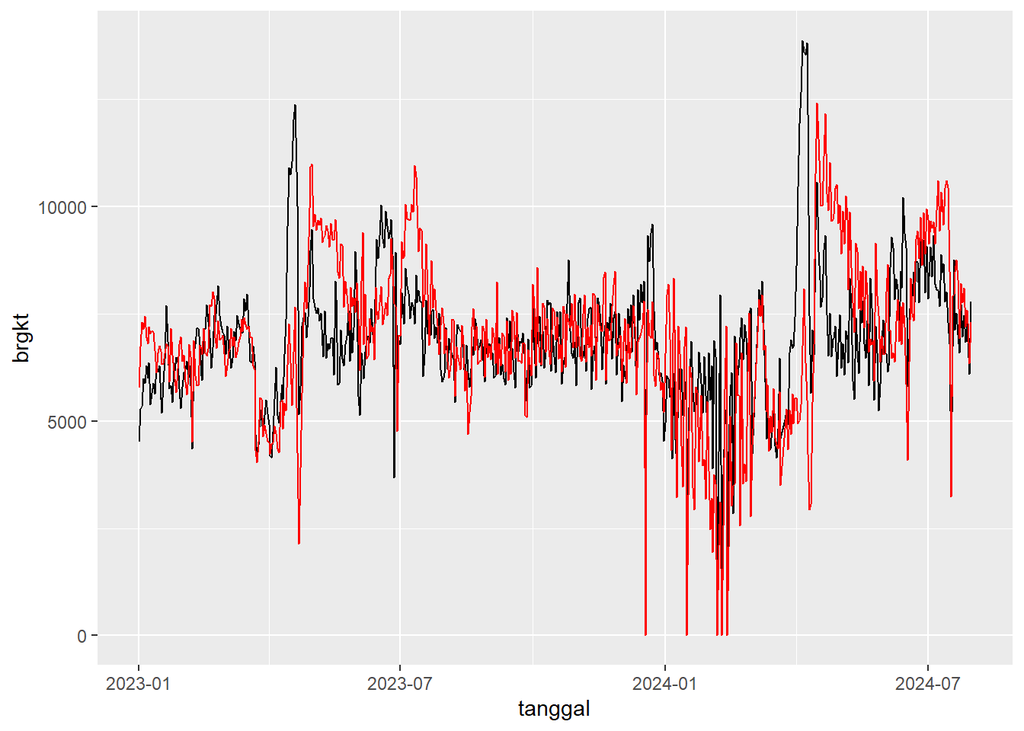

```r
ggplot(dt, aes(tanggal, brgkt)) +
  geom_line() +
  geom_line(aes(tanggal, tiba), color = "red")
```

Ada beberapa yang memiliki nilai 0. Perlu di telusuri mengapa hal ini terjadi.

```r
dt %>% filter(brgkt==0 | tiba==0)
```

```
##      tanggal brgkt tiba
## 1 2023-12-18     0    0
## 2 2024-01-16     0    0
## 3 2024-02-06     0    0
## 4 2024-02-09     0    0
## 5 2024-02-13     0    0
```

terdapat 5 data yang memiliki nilai 0. Tidak ada berita yang mengidikasikan bandara ditutup pada tanggal yang bersangkutan. Maka, data ini dianggap sebagai data yang hilang dan perlu diimputasi.

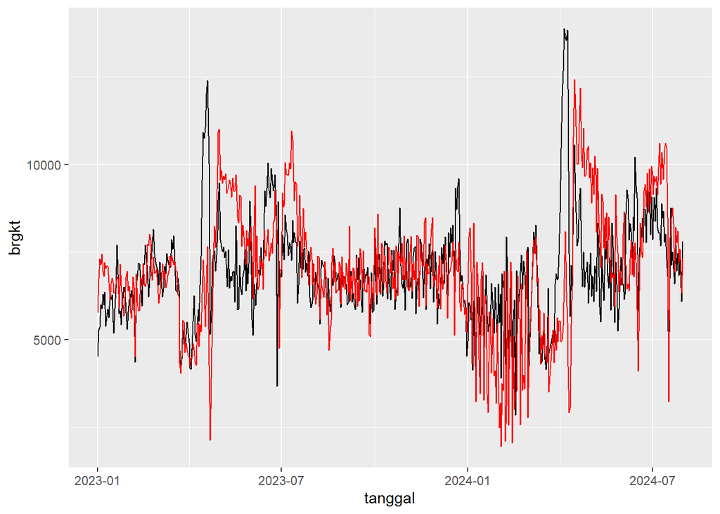

```r
# Imputasi dengan Median
dt <- dt %>% mutate(brgkt = ifelse(brgkt==0, median(brgkt,na.rm=T), brgkt),
                    tiba = ifelse(tiba==0, median(tiba,na.rm=T), tiba))
## Plot untuk cek
ggplot(dt, aes(tanggal, brgkt)) +
  geom_line() +
  geom_line(aes(tanggal, tiba), color = "red")
```

Sudah aman.

```r
dt$passenger <- dt$brgkt + dt$tiba
summary(dt)
```

```
##     tanggal               brgkt            tiba         passenger
##  Min.   :2023-01-01   Min.   : 2844   Min.   : 1944   Min.   : 5846
##  1st Qu.:2023-05-23   1st Qu.: 6078   1st Qu.: 6170   1st Qu.:12447
##  Median :2023-10-13   Median : 6824   Median : 6952   Median :13975
##  Mean   :2023-10-14   Mean   : 6951   Mean   : 7010   Mean   :13961
##  3rd Qu.:2024-03-08   3rd Qu.: 7600   3rd Qu.: 7937   3rd Qu.:15710
##  Max.   :2024-07-31   Max.   :13869   Max.   :12414   Max.   :22978
```

```r
#write.csv(dt, "D:\\IPB\\5\\MPDW\\data\\passenger.csv")
```

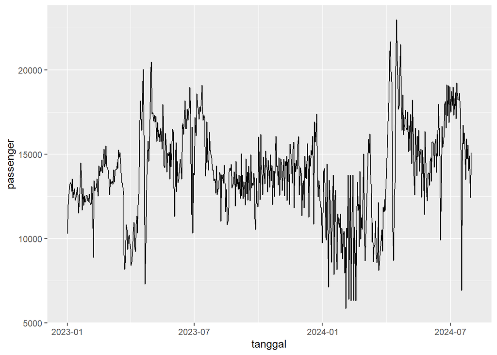

```r
ggplot(dt, aes(tanggal, passenger)) +
  geom_line()
```

Data yang kita miliki memiliki fluktuasi yang cukup tinggi. Ini mengingingidikasikan data yang kita miliki tidak stasioner.

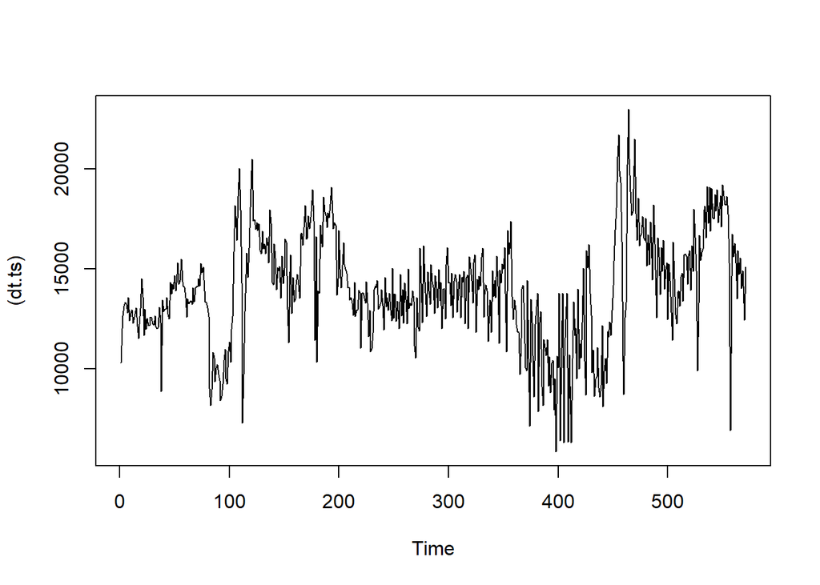

```r
dt.ts <- ts((dt$passenger))
plot((dt.ts))
```

### Train Test Split

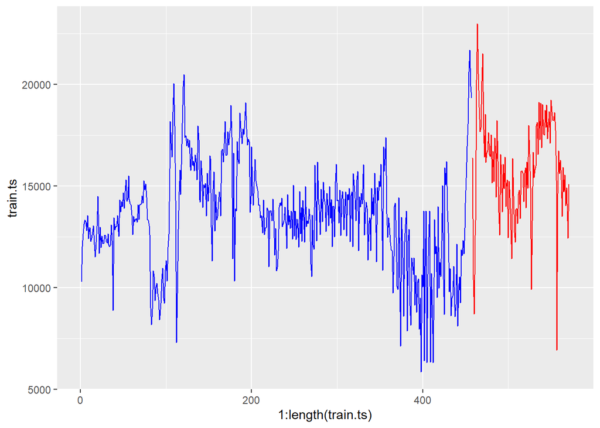

```r
train.ts <- dt.ts[1:round(length(dt.ts)*0.8)] %>% ts()
test.ts <- dt.ts[(round(length(dt.ts)*0.8)+1):length(dt.ts)] %>% ts()

## plot data train and test
ggplot()+
  geom_line(aes(x=1:length(train.ts), y=train.ts), color="blue")+
  geom_line(aes(x=(1:length(test.ts)+length(train.ts)), y=test.ts), color="red")
```

train test split process sudah sesuai.

## Eksplorasi Train Data

```r
model.auto <- auto.arima(train.ts)
lmtest::coeftest(model.auto)
```

```
##
## z test of coefficients:
##
##      Estimate Std. Error z value Pr(>|z|)
## ar1  0.141123   0.089200  1.5821   0.1136
## ma1 -0.660928   0.070669 -9.3525   <2e-16 ***
## ---
## Signif. codes:  0 '***' 0.001 '**' 0.01 '*' 0.05 '.' 0.1 ' ' 1
```

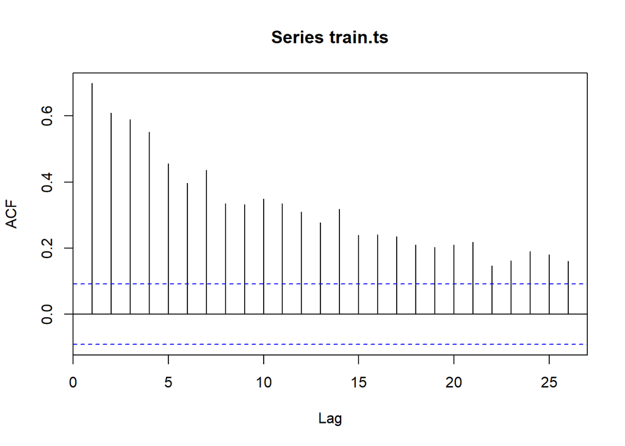

```r
acf(train.ts)
```

data yang kita miliki memiliki acf yang very slowly tails off mengindikasikan data yang tidak stasioner.

```r
adf.test(train.ts)
```

```
##
##  Augmented Dickey-Fuller Test
##
## data:  train.ts
## Dickey-Fuller = -3.7139, Lag order = 7, p-value = 0.02339
## alternative hypothesis: stationary
```

Hasil adf.test menunjukan tolak H0 yang artinya data sudah stasioner. Walaupun begitu, kita akan tetap menganggap data tidak staisoner dalam rataan

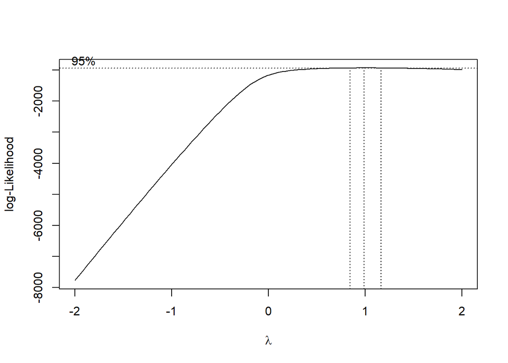

```r
index.train <- 1:length(train.ts)
bc.train.ts <- boxcox(train.ts - (min(train.ts)-1) ~ index.train, lambda = seq(-2, 2, 0.1))
```

Boxcox mengandung nilai 1 yang mengindikasikan data yang kita miliki tidak memerlukan transformasi dan stasioner dalam ragam.

### Differencing

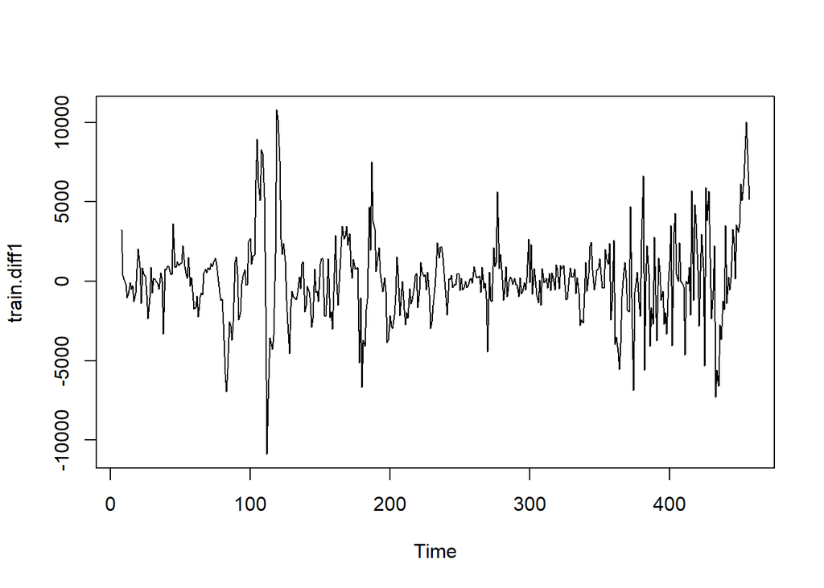

```r
train.diff1 <- diff(train.ts,lag=7)
plot(train.diff1)
```

hasil differencing menunjukan data yang kita miliki sudah stasioner dalam rataan.

```r
adf.test(train.diff1)
```

```
##
##  Augmented Dickey-Fuller Test
##
## data:  train.diff1
## Dickey-Fuller = -7.0959, Lag order = 7, p-value = 0.01
## alternative hypothesis: stationary
```

Sudah stasioner dalam rataan.

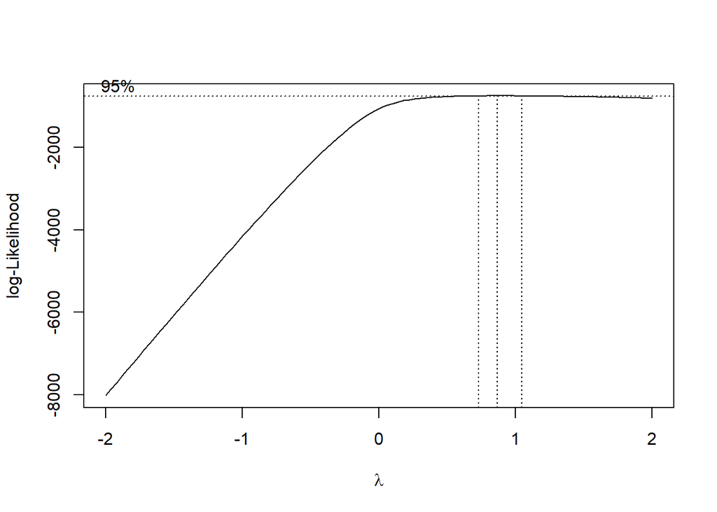

```r
index.train.diff1 <- 1:length(train.diff1)
bc.train.diff1 <- boxcox(train.diff1 - (min(train.diff1)-1) ~ index.train.diff1, lambda = seq(-2, 2, 0.1))
```

Boxcox mengandung angka 1 sehingga sudah tidak memerlukan transformasi.

## Identifikasi Model

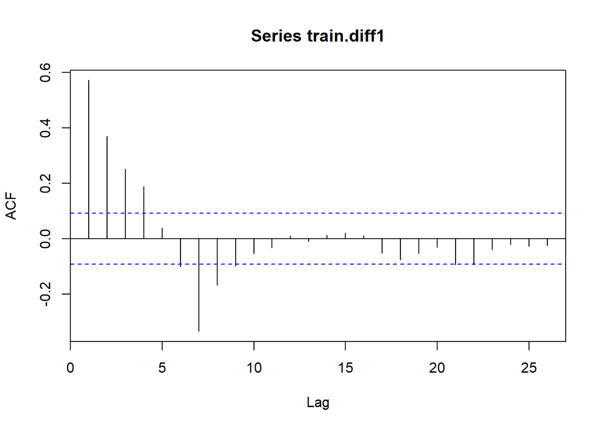

```r
acf(train.diff1)
```

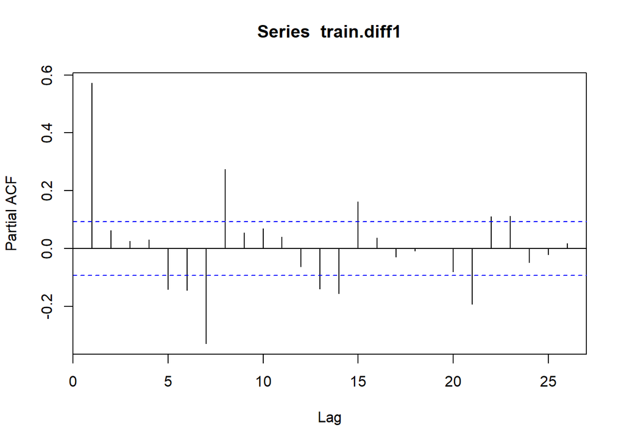

```r
pacf(train.diff1)
```

```r
eacf(train.diff1)
```

```
## AR/MA
##   0 1 2 3 4 5 6 7 8 9 10 11 12 13
## 0 x x x x o x x x x o o  o  o  o
## 1 x o o x o o x o o o o  o  o  o
## 2 x o o x o o x o o o o  o  o  o
## 3 x o o x o o x o o o o  o  o  o
## 4 x x x o o o x x o o o  o  o  o
## 5 x x x x o x x x o x o  o  o  o
## 6 x x x o o x x x o x o  o  o  o
## 7 x x x x x o x x x o o  o  o  o
```

```r
auto.arima(train.diff1)
```

```
## Series: train.diff1
## ARIMA(1,0,1) with zero mean
##
## Coefficients:
##          ar1      ma1
##       0.6656  -0.1322
## s.e.  0.0630   0.0842
##
## sigma^2 = 4593870:  log likelihood = -4089.28
## AIC=8184.56   AICc=8184.62   BIC=8196.89
```

ARIMA(1,0,1)(0,1,1)7 ARIMA(1,0,0)(0,1,1)7 ARIMA(0,0,4)(0,1,1)7 ARIMA(1,0,4)(0,1,1)7 ARIMA(3,0,1)(0,1,1)7

```r
model1 <- Arima(train.ts, order = c(1,0,1), seasonal = list(order = c(0,1,1), period = 7))
summary(model1)
```

```
## Series: train.ts
## ARIMA(1,0,1)(0,1,1)[7]
##
## Coefficients:
##          ar1      ma1     sma1
##       0.9117  -0.4117  -0.9361
## s.e.  0.0293   0.0615   0.0311
##
## sigma^2 = 2723286:  log likelihood = -3978.07
## AIC=7964.15   AICc=7964.24   BIC=7980.58
##
## Training set error measures:
##                    ME     RMSE      MAE       MPE     MAPE      MASE       ACF1
## Training set 24.32243 1632.083 1127.132 -1.616501 9.420506 0.7964091 0.02570457
```

```r
lmtest::coeftest(model1)
```

```
##
## z test of coefficients:
##
##       Estimate Std. Error  z value  Pr(>|z|)
## ar1   0.911739   0.029327  31.0886 < 2.2e-16 ***
## ma1  -0.411656   0.061463  -6.6976 2.119e-11 ***
## sma1 -0.936084   0.031102 -30.0976 < 2.2e-16 ***
## ---
## Signif. codes:  0 '***' 0.001 '**' 0.01 '*' 0.05 '.' 0.1 ' ' 1
```

```r
model2 <- Arima(train.ts, order = c(1,0,0), seasonal = list(order = c(0,1,1), period = 7))
summary(model2)
```

```
## Series: train.ts
## ARIMA(1,0,0)(0,1,1)[7]
##
## Coefficients:
##          ar1     sma1
##       0.7185  -0.8886
## s.e.  0.0346   0.0318
##
## sigma^2 = 2926364:  log likelihood = -3993.33
## AIC=7992.67   AICc=7992.72   BIC=8005
##
## Training set error measures:
##                   ME     RMSE      MAE       MPE   MAPE      MASE       ACF1
## Training set 8.51936 1693.734 1171.527 -1.840677 9.8233 0.8277781 -0.1428248
```

```r
lmtest::coeftest(model2)
```

```
##
## z test of coefficients:
##
##       Estimate Std. Error z value  Pr(>|z|)
## ar1   0.718515   0.034588  20.774 < 2.2e-16 ***
## sma1 -0.888641   0.031842 -27.908 < 2.2e-16 ***
## ---
## Signif. codes:  0 '***' 0.001 '**' 0.01 '*' 0.05 '.' 0.1 ' ' 1
```

```r
model3 <- Arima(train.ts, order = c(0,0,4), seasonal = list(order = c(0,1,1), period = 7))
summary(model3)
```

```
## Series: train.ts
## ARIMA(0,0,4)(0,1,1)[7]
##
## Coefficients:
##          ma1     ma2     ma3     ma4     sma1
##       0.5478  0.3898  0.2904  0.2537  -0.8590
## s.e.  0.0496  0.0539  0.0447  0.0456   0.0361
##
## sigma^2 = 3036488:  log likelihood = -3999.34
## AIC=8010.68   AICc=8010.87   BIC=8035.34
##
## Training set error measures:
##                    ME     RMSE      MAE       MPE     MAPE     MASE       ACF1
## Training set 6.134173 1719.522 1210.218 -2.034251 10.00154 0.855116 0.05456914
```

```r
lmtest::coeftest(model3)
```

```
##
## z test of coefficients:
##
##       Estimate Std. Error  z value  Pr(>|z|)
## ma1   0.547772   0.049575  11.0492 < 2.2e-16 ***
## ma2   0.389830   0.053941   7.2270 4.937e-13 ***
## ma3   0.290415   0.044724   6.4935 8.386e-11 ***
## ma4   0.253739   0.045591   5.5655 2.613e-08 ***
## sma1 -0.858965   0.036134 -23.7715 < 2.2e-16 ***
## ---
## Signif. codes:  0 '***' 0.001 '**' 0.01 '*' 0.05 '.' 0.1 ' ' 1
```

```r
model4 <- Arima(train.ts, order = c(1,0,4), seasonal = list(order = c(0,1,1), period = 7))
summary(model4)
```

```
## Series: train.ts
## ARIMA(1,0,4)(0,1,1)[7]
##
## Coefficients:
##         ar1      ma1      ma2     ma3     ma4     sma1
##       0.878  -0.3420  -0.0574  0.0389  0.0845  -0.9289
## s.e.  0.059   0.0772   0.0597  0.0591  0.0676   0.0338
##
## sigma^2 = 2715620:  log likelihood = -3975.75
## AIC=7965.49   AICc=7965.75   BIC=7994.26
##
## Training set error measures:
##                    ME     RMSE      MAE       MPE     MAPE      MASE
## Training set 20.99909 1624.306 1119.857 -1.631312 9.374142 0.7912686
##                      ACF1
## Training set -0.004479121
```

```r
lmtest::coeftest(model4)
```

```
##
## z test of coefficients:
##
##       Estimate Std. Error  z value  Pr(>|z|)
## ar1   0.878020   0.059047  14.8700 < 2.2e-16 ***
## ma1  -0.342045   0.077157  -4.4331 9.288e-06 ***
## ma2  -0.057352   0.059675  -0.9611    0.3365
## ma3   0.038922   0.059085   0.6588    0.5101
## ma4   0.084479   0.067644   1.2489    0.2117
## sma1 -0.928876   0.033827 -27.4600 < 2.2e-16 ***
## ---
## Signif. codes:  0 '***' 0.001 '**' 0.01 '*' 0.05 '.' 0.1 ' ' 1
```

```r
model5 <- Arima(train.ts, order = c(3,0,1), seasonal = list(order = c(0,1,1), period = 7))
summary(model5)
```

```
## Series: train.ts
## ARIMA(3,0,1)(0,1,1)[7]
##
## Coefficients:
##          ar1      ar2     ar3      ma1     sma1
##       0.8730  -0.0695  0.1031  -0.3428  -0.9373
## s.e.  0.1951   0.1184  0.0718   0.1932   0.0319
##
## sigma^2 = 2714144:  log likelihood = -3976.33
## AIC=7964.65   AICc=7964.84   BIC=7989.31
##
## Training set error measures:
##                    ME     RMSE     MAE       MPE     MAPE      MASE        ACF1
## Training set 26.03945 1625.692 1118.35 -1.589577 9.362655 0.7902039 -0.00317631
```

```r
lmtest::coeftest(model5)
```

```
##
## z test of coefficients:
##
##       Estimate Std. Error  z value  Pr(>|z|)
## ar1   0.873005   0.195120   4.4742  7.67e-06 ***
## ar2  -0.069466   0.118399  -0.5867    0.5574
## ar3   0.103123   0.071799   1.4363    0.1509
## ma1  -0.342810   0.193198  -1.7744    0.0760 .
## sma1 -0.937277   0.031947 -29.3383 < 2.2e-16 ***
## ---
## Signif. codes:  0 '***' 0.001 '**' 0.01 '*' 0.05 '.' 0.1 ' ' 1
```

ARIMA(1,0,1)(0,1,1)[7]

### Overfitting

```r
model6 <- Arima(train.ts, order = c(2,0,1), seasonal = list(order = c(0,1,1), period = 7))
summary(model6)
```

```
## Series: train.ts
## ARIMA(2,0,1)(0,1,1)[7]
##
## Coefficients:
##          ar1      ar2      ma1    sma1
##       1.0819  -0.1421  -0.5561  -0.938
## s.e.  0.1255   0.1055   0.1115   0.031
##
## sigma^2 = 2718329:  log likelihood = -3977.14
## AIC=7964.29   AICc=7964.42   BIC=7984.83
##
## Training set error measures:
##                    ME     RMSE      MAE       MPE     MAPE      MASE       ACF1
## Training set 27.34126 1628.772 1122.172 -1.582056 9.386168 0.7929048 0.00313188
```

```r
lmtest::coeftest(model6)
```

```
##
## z test of coefficients:
##
##       Estimate Std. Error  z value  Pr(>|z|)
## ar1   1.081906   0.125542   8.6179 < 2.2e-16 ***
## ar2  -0.142074   0.105480  -1.3469     0.178
## ma1  -0.556097   0.111466  -4.9889 6.071e-07 ***
## sma1 -0.937962   0.031029 -30.2286 < 2.2e-16 ***
## ---
## Signif. codes:  0 '***' 0.001 '**' 0.01 '*' 0.05 '.' 0.1 ' ' 1
```

```r
model7 <- Arima(train.ts, order = c(1,0,2), seasonal = list(order = c(0,1,1), period = 7))
summary(model7)
```

```
## Series: train.ts
## ARIMA(1,0,2)(0,1,1)[7]
##
## Coefficients:
##          ar1      ma1      ma2     sma1
##       0.9294  -0.3963  -0.0801  -0.9379
## s.e.  0.0278   0.0558   0.0521   0.0312
##
## sigma^2 = 2715467:  log likelihood = -3976.9
## AIC=7963.8   AICc=7963.94   BIC=7984.35
##
## Training set error measures:
##                    ME     RMSE     MAE       MPE     MAPE      MASE
## Training set 27.50988 1627.915 1120.57 -1.578742 9.376832 0.7917724
##                      ACF1
## Training set -0.003799288
```

```r
lmtest::coeftest(model7)
```

```
##
## z test of coefficients:
##
##       Estimate Std. Error  z value  Pr(>|z|)
## ar1   0.929361   0.027781  33.4534 < 2.2e-16 ***
## ma1  -0.396285   0.055848  -7.0957 1.287e-12 ***
## ma2  -0.080064   0.052066  -1.5377    0.1241
## sma1 -0.937926   0.031197 -30.0645 < 2.2e-16 ***
## ---
## Signif. codes:  0 '***' 0.001 '**' 0.01 '*' 0.05 '.' 0.1 ' ' 1
```

```r
model8 <- Arima(train.ts, order = c(1,0,1), seasonal = list(order = c(0,1,2), period = 7))
summary(model8)
```

```
## Series: train.ts
## ARIMA(1,0,1)(0,1,2)[7]
##
## Coefficients:
##          ar1      ma1     sma1     sma2
##       0.9053  -0.3994  -0.9014  -0.0427
## s.e.  0.0314   0.0641   0.0516   0.0509
##
## sigma^2 = 2720805:  log likelihood = -3977.72
## AIC=7965.45   AICc=7965.58   BIC=7985.99
##
## Training set error measures:
##                    ME     RMSE      MAE       MPE     MAPE      MASE       ACF1
## Training set 24.67088 1629.514 1124.818 -1.622926 9.404807 0.7947739 0.02439721
```

```r
lmtest::coeftest(model8)
```

```
##
## z test of coefficients:
##
##       Estimate Std. Error  z value  Pr(>|z|)
## ar1   0.905346   0.031388  28.8437 < 2.2e-16 ***
## ma1  -0.399369   0.064086  -6.2318 4.612e-10 ***
## sma1 -0.901428   0.051561 -17.4828 < 2.2e-16 ***
## sma2 -0.042696   0.050921  -0.8385    0.4018
## ---
## Signif. codes:  0 '***' 0.001 '**' 0.01 '*' 0.05 '.' 0.1 ' ' 1
```

```r
model9 <- Arima(train.ts, order = c(1,0,1), seasonal = list(order = c(1,1,1), period = 7))
summary(model9)
```

```
## Series: train.ts
## ARIMA(1,0,1)(1,1,1)[7]
##
## Coefficients:
##          ar1      ma1    sar1     sma1
##       0.9045  -0.3979  0.0507  -0.9484
## s.e.  0.0317   0.0644  0.0577   0.0338
##
## sigma^2 = 2719441:  log likelihood = -3977.69
## AIC=7965.37   AICc=7965.51   BIC=7985.92
##
## Training set error measures:
##                    ME     RMSE      MAE       MPE     MAPE      MASE       ACF1
## Training set 24.82702 1629.105 1124.714 -1.623259 9.404089 0.7947006 0.02429839
```

```r
lmtest::coeftest(model9)
```

```
##
## z test of coefficients:
##
##       Estimate Std. Error  z value  Pr(>|z|)
## ar1   0.904504   0.031710  28.5238 < 2.2e-16 ***
## ma1  -0.397949   0.064426  -6.1769 6.539e-10 ***
## sar1  0.050664   0.057745   0.8774    0.3803
## sma1 -0.948418   0.033796 -28.0632 < 2.2e-16 ***
## ---
## Signif. codes:  0 '***' 0.001 '**' 0.01 '*' 0.05 '.' 0.1 ' ' 1
```

## Diagnostik sisaan

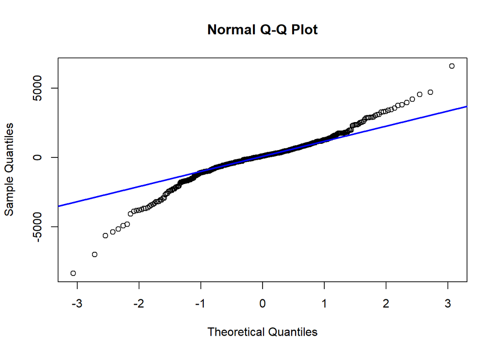

```r
sisaan <- model1$residuals
qqnorm(sisaan)
qqline(sisaan, col = "blue", lwd = 2)
```

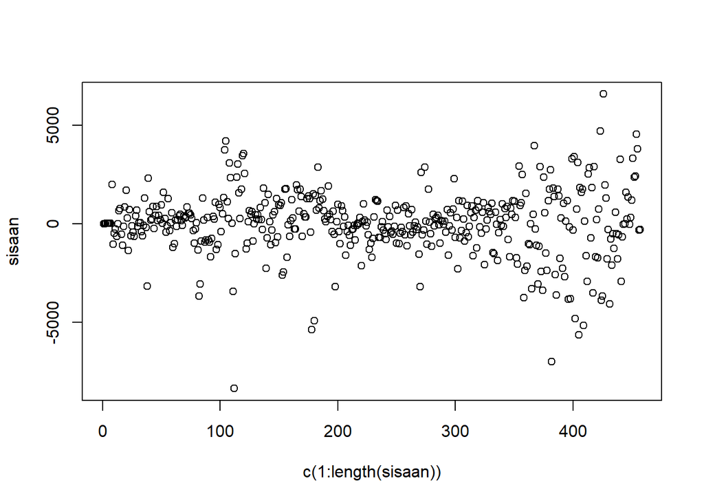

```r
plot(c(1:length(sisaan)),sisaan)
```

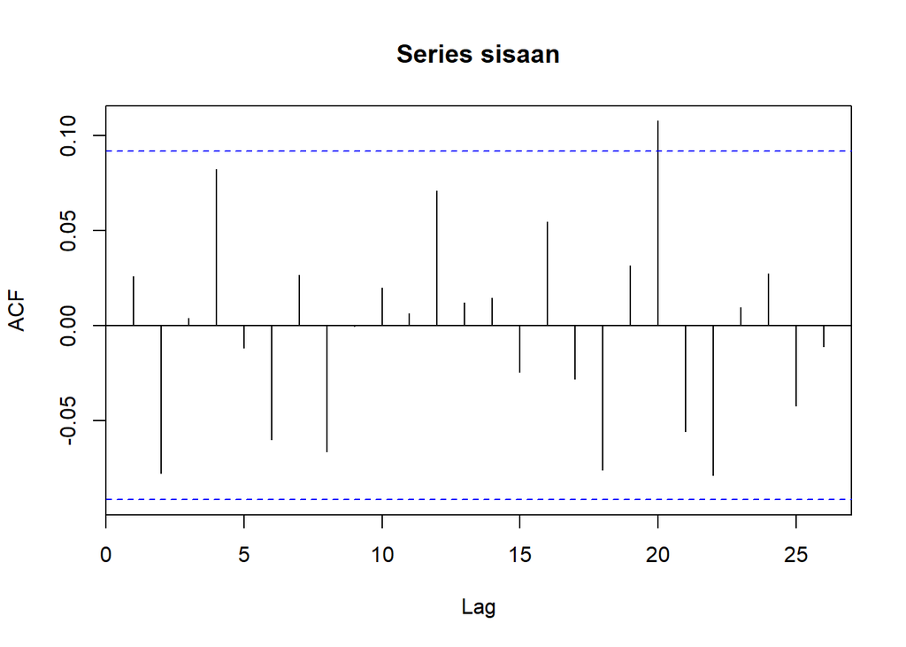

```r
acf(sisaan)
```

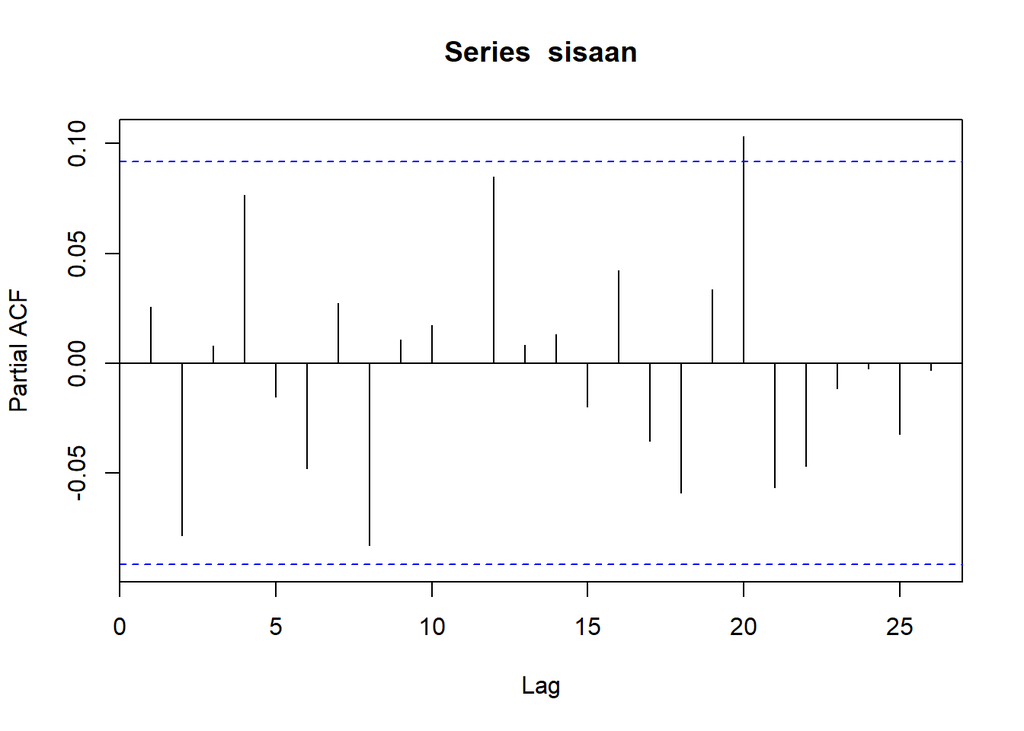

```r
pacf(sisaan)
```

```r
shapiro.test(sisaan)
```

```
##
##  Shapiro-Wilk normality test
##
## data:  sisaan
## W = 0.94355, p-value = 3.587e-12
```

```r
Box.test(sisaan, type = "Ljung-Box")
```

```
##
##  Box-Ljung test
##
## data:  sisaan
## X-squared = 0.30394, df = 1, p-value = 0.5814
```

```r
Box.test(sisaan^2, type = "Ljung-Box")
```

```
##
##  Box-Ljung test
##
## data:  sisaan^2
## X-squared = 20.657, df = 1, p-value = 5.493e-06
```

### Uji Efek ARCH LM

```r
for(i in seq(2,24,2)){
  cat("Lags: ",i,"\n")
  print(ArchTest(sisaan, lags = i)$p.value)
}
```

```
## Lags:  2
##  Chi-squared
## 5.684849e-06
## Lags:  4
##  Chi-squared
## 8.552497e-09
## Lags:  6
##  Chi-squared
## 1.122187e-07
## Lags:  8
##  Chi-squared
## 1.726962e-10
## Lags:  10
##  Chi-squared
## 4.723308e-10
## Lags:  12
##  Chi-squared
## 1.639468e-09
## Lags:  14
## Chi-squared
## 1.71057e-09
## Lags:  16
## Chi-squared
## 1.01218e-08
## Lags:  18
##  Chi-squared
## 4.797459e-08
## Lags:  20
##  Chi-squared
## 1.179957e-07
## Lags:  22
## Chi-squared
## 4.23453e-07
## Lags:  24
##  Chi-squared
## 9.405448e-07
```

## GARCH

```r
res.arima211 <- scale(model1$residuals)
garch01=garch(x=res.arima211,order=c(0,1))
```

[output not shown]

```r
AIC(garch01)
```

```
## [1] 1210.489
```

```r
lmtest::coeftest(garch01)
```

```
##
## z test of coefficients:
##
##    Estimate Std. Error z value  Pr(>|z|)
## a0 0.510347   0.031229  16.342 < 2.2e-16 ***
## a1 0.584198   0.086934   6.720 1.817e-11 ***
## ---
## Signif. codes:  0 '***' 0.001 '**' 0.01 '*' 0.05 '.' 0.1 ' ' 1
```

```r
garch02=garch(x=res.arima211,order=c(0,2))
```

[output not shown]

```r
AIC(garch02)
```

```
## [1] 1171.694
```

```r
lmtest::coeftest(garch02)
```

```
##
## z test of coefficients:
##
##    Estimate Std. Error z value  Pr(>|z|)
## a0 0.277114   0.034809  7.9609 1.708e-15 ***
## a1 0.607399   0.086454  7.0257 2.130e-12 ***
## a2 0.364192   0.071634  5.0841 3.694e-07 ***
## ---
## Signif. codes:  0 '***' 0.001 '**' 0.01 '*' 0.05 '.' 0.1 ' ' 1
```

```r
garch03=garch(x=res.arima211,order=c(0,3))
```

[output not shown]

```r
AIC(garch03)
```

```
## [1] 1153.584
```

```r
lmtest::coeftest(garch03)
```

```
##
## z test of coefficients:
##
##    Estimate Std. Error z value  Pr(>|z|)
## a0 0.236323   0.031592  7.4804 7.412e-14 ***
## a1 0.479225   0.075111  6.3802 1.768e-10 ***
## a2 0.282356   0.063134  4.4723 7.738e-06 ***
## a3 0.180191   0.061794  2.9160  0.003546 **
## ---
## Signif. codes:  0 '***' 0.001 '**' 0.01 '*' 0.05 '.' 0.1 ' ' 1
```

```r
garch04=garch(x=res.arima211,order=c(0,4))
```

[output not shown]

```r
AIC(garch04)
```

```
## [1] 1145.942
```

```r
lmtest::coeftest(garch04)
```

```
##
## z test of coefficients:
##
##    Estimate Std. Error z value  Pr(>|z|)
## a0 0.213745   0.028316  7.5486 4.399e-14 ***
## a1 0.390592   0.079575  4.9085 9.179e-07 ***
## a2 0.233300   0.066136  3.5276 0.0004194 ***
## a3 0.123867   0.057184  2.1661 0.0303017 *
## a4 0.180216   0.071069  2.5358 0.0112201 *
## ---
## Signif. codes:  0 '***' 0.001 '**' 0.01 '*' 0.05 '.' 0.1 ' ' 1
```

```r
garch05=garch(x=res.arima211,order=c(0,5))
```

[output not shown]

[output cut: 46 more lines]

```r
AIC(garch05)
```

```
## [1] 1145.407
```

```r
lmtest::coeftest(garch05)
```

```
##
## z test of coefficients:
##
##    Estimate Std. Error z value  Pr(>|z|)
## a0 0.211159   0.028854  7.3182 2.514e-13 ***
## a1 0.411208   0.079038  5.2026 1.965e-07 ***
## a2 0.199709   0.062545  3.1931  0.001408 **
## a3 0.109889   0.057818  1.9006  0.057354 .
## a4 0.142255   0.069405  2.0496  0.040401 *
## a5 0.056273   0.040891  1.3762  0.168772
## ---
## Signif. codes:  0 '***' 0.001 '**' 0.01 '*' 0.05 '.' 0.1 ' ' 1
```

```r
garch06=garch(x=res.arima211,order=c(0,6))
```

[output not shown]

[output cut: 56 more lines]

```r
AIC(garch06)
```

```
## [1] 1187.71
```

```r
garch07=garch(x=res.arima211,order=c(0,7))
```

[output not shown]

[output cut: 61 more lines]

```r
AIC(garch07)
```

```
## [1] 1180.681
```

```r
lmtest::coeftest(garch07)
```

```
##
## z test of coefficients:
##
##      Estimate Std. Error z value Pr(>|z|)
## a0 5.3319e-01 6.4904e-02  8.2151  < 2e-16 ***
## a1 1.4291e-01 6.1703e-02  2.3162  0.02055 *
## a2 7.5446e-02 4.3027e-02  1.7534  0.07953 .
## a3 8.5731e-02 5.9240e-02  1.4472  0.14785
## a4 6.8623e-02 7.1529e-02  0.9594  0.33737
## a5 2.3340e-02 5.2390e-02  0.4455  0.65595
## a6 4.2730e-15 4.9492e-02  0.0000  1.00000
## a7 9.1174e-02 5.9873e-02  1.5228  0.12781
## ---
## Signif. codes:  0 '***' 0.001 '**' 0.01 '*' 0.05 '.' 0.1 ' ' 1
```

```r
garch08=garch(x=res.arima211,order=c(0,8))
```

[output not shown]

[output cut: 59 more lines]

```r
AIC(garch08)
```

```
## [1] 1173.19
```

```r
garch09=garch(x=res.arima211,order=c(0,9))
```

[output not shown]

[output cut: 63 more lines]

```r
AIC(garch09)
```

```
## [1] 1168.01
```

```r
garch10=garch(x=res.arima211,order=c(0,10))
```

[output not shown]

[output cut: 62 more lines]

```r
AIC(garch10)
```

```
## [1] 1162.817
```

```r
lmtest::coeftest(garch10)
```

```
##
## z test of coefficients:
##
##       Estimate Std. Error z value  Pr(>|z|)
## a0  4.0525e-01 5.2310e-02  7.7472 9.393e-15 ***
## a1  1.4378e-01 5.8994e-02  2.4372   0.01480 *
## a2  7.5637e-02 3.9475e-02  1.9161   0.05536 .
## a3  8.3645e-02 5.4989e-02  1.5211   0.12823
## a4  6.4378e-02 6.4236e-02  1.0022   0.31624
## a5  1.3596e-02 5.0077e-02  0.2715   0.78601
## a6  3.6524e-15 4.7004e-02  0.0000   1.00000
## a7  7.7687e-02 6.1382e-02  1.2656   0.20565
## a8  4.0548e-02 5.7988e-02  0.6993   0.48439
## a9  4.2866e-02 5.2907e-02  0.8102   0.41782
## a10 9.0950e-03 3.8885e-02  0.2339   0.81507
## ---
## Signif. codes:  0 '***' 0.001 '**' 0.01 '*' 0.05 '.' 0.1 ' ' 1
```

```r
garch11=garch(x=res.arima211,order=c(1,1))
```

[output not shown]

[output cut: 53 more lines]

```r
AIC(garch11)
```

```
## [1] 1239.169
```

```r
lmtest::coeftest(garch11)
```

```
##
## z test of coefficients:
##
##      Estimate Std. Error z value  Pr(>|z|)
## a0 8.1003e-01 1.1709e-01  6.9179 4.584e-12 ***
## a1 2.3989e-01 4.5296e-02  5.2961 1.183e-07 ***
## b1 6.1607e-16 8.3325e-02  0.0000         1
## ---
## Signif. codes:  0 '***' 0.001 '**' 0.01 '*' 0.05 '.' 0.1 ' ' 1
```

```r
garch12=garch(x=res.arima211,order=c(1,2))
```

[output not shown]

[output cut: 50 more lines]

```r
AIC(garch12)
```

```
## [1] 1229.032
```

```r
lmtest::coeftest(garch12)
```

```
##
## z test of coefficients:
##
##      Estimate Std. Error z value  Pr(>|z|)
## a0 7.6411e-01 2.2949e-01  3.3296 0.0008698 ***
## a1 1.9999e-01 4.2859e-02  4.6662 3.068e-06 ***
## a2 1.0209e-01 7.7622e-02  1.3152 0.1884550
## b1 6.8720e-15 2.5685e-01  0.0000 1.0000000
## ---
## Signif. codes:  0 '***' 0.001 '**' 0.01 '*' 0.05 '.' 0.1 ' ' 1
```

```r
garch13=garch(x=res.arima211,order=c(1,3))
```

[output not shown]

[output cut: 56 more lines]

```r
AIC(garch13)
```

```
## [1] 1215.657
```

```r
lmtest::coeftest(garch13)
```

```
##
## z test of coefficients:
##
##      Estimate Std. Error z value  Pr(>|z|)
## a0 7.1620e-01 1.7235e-01  4.1555 3.246e-05 ***
## a1 1.5556e-01 4.7318e-02  3.2875  0.001011 **
## a2 8.3839e-02 5.9391e-02  1.4116  0.158056
## a3 1.1807e-01 7.1077e-02  1.6612  0.096682 .
## b1 2.1596e-15 1.9228e-01  0.0000  1.000000
## ---
## Signif. codes:  0 '***' 0.001 '**' 0.01 '*' 0.05 '.' 0.1 ' ' 1
```

```r
garch21=garch(x=res.arima211,order=c(2,1))
```

[output not shown]

[output cut: 47 more lines]

```r
AIC(garch21)
```

```
## [1] 1142.529
```

```r
lmtest::coeftest(garch21)
```

```
##
## z test of coefficients:
##
##    Estimate Std. Error z value  Pr(>|z|)
## a0 0.081939   0.020312  4.0340 5.485e-05 ***
## a1 0.401561   0.069411  5.7853 7.238e-09 ***
## b1 0.403512   0.148494  2.7174  0.006581 **
## b2 0.161052   0.120655  1.3348  0.181939
## ---
## Signif. codes:  0 '***' 0.001 '**' 0.01 '*' 0.05 '.' 0.1 ' ' 1
```

```r
garch22=garch(x=res.arima211,order=c(2,2))
```

[output not shown]

[output cut: 47 more lines]

```r
AIC(garch22)
```

```
## [1] 1226.737
```

```r
lmtest::coeftest(garch22)
```

```
##
## z test of coefficients:
##
##      Estimate Std. Error z value  Pr(>|z|)
## a0 7.1804e-01 2.4924e-01  2.8809  0.003965 **
## a1 1.9353e-01 4.2054e-02  4.6019 4.187e-06 ***
## a2 1.0365e-01 1.0690e-01  0.9696  0.332263
## b1 1.8302e-15 4.8042e-01  0.0000  1.000000
## b2 1.2323e-02 2.0474e-01  0.0602  0.952004
## ---
## Signif. codes:  0 '***' 0.001 '**' 0.01 '*' 0.05 '.' 0.1 ' ' 1
```

GARCH(0,4)

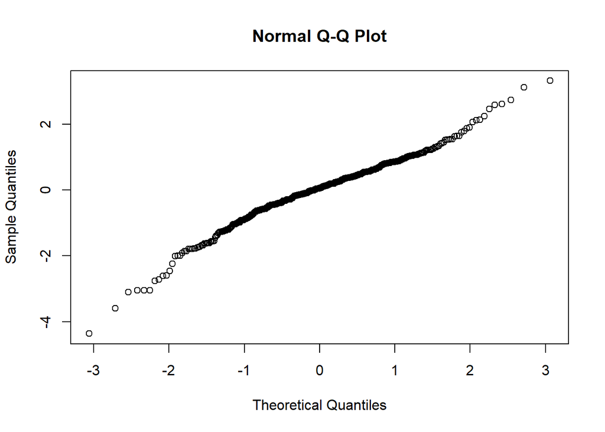

```r
gar.res <- garch04$residuals
qqnorm(gar.res)
```

```r
shapiro.test(gar.res)
```

```
##
##  Shapiro-Wilk normality test
##
## data:  gar.res
## W = 0.97339, p-value = 2.423e-07
```

```r
Box.test(gar.res, type = "Ljung-Box")
```

```
##
##  Box-Ljung test
##
## data:  gar.res
## X-squared = 2.264, df = 1, p-value = 0.1324
```

```r
Box.test(gar.res^2, type = "Ljung-Box")
```

```
##
##  Box-Ljung test
##
## data:  gar.res^2
## X-squared = 0.0057101, df = 1, p-value = 0.9398
```